# Exercise 03

Hubert Rehrauer

04 10 2021

## Exploratory Data Analysis

Do an exploratory data analysis of a matrix of expression values. The data consists of expression values for samples that were treated with DMSO and TSA. The samples were measured using three technologies: bulk, IFC96, IFC800. See the two RDS files `counts.RDS` and `phenodata.RDS`

## Compute and visualize basic statistics

How many replicates are there for each combination of factor levels?

```r
table(anno)
```

```
##          Technology
## Treatment bulk IFC800 IFC96
##      DMSO    3     20    20
##      TSA     3     20    20
```

How many genes have an expression value above 0 in each sample?

```r
colSums(x != 0)
```

```
##                      bulk.DMSO-Pre-96IFC
##                                    15163
##                       bulk.TSA-Pre-96IFC
##                                    15261
##                     bulk.DMSO-Pre-800IFC
##                                    15404
##                      bulk.TSA-Pre-800IFC
##                                    16182
##                    bulk.DMSO-Post-800IFC
##                                    15202
##                     bulk.TSA-Post-800IFC
##                                    16167
##     ifc96.LIB018588_GEN00046618_S78_L001
##                                     7862
##     ifc96.LIB018588_GEN00046619_S79_L001
##                                     8537
##     ifc96.LIB018588_GEN00046620_S80_L001
##                                      404
##     ifc96.LIB018588_GEN00046621_S81_L001
##                                     7479
##     ifc96.LIB018588_GEN00046622_S82_L001
##                                     7003
##     ifc96.LIB018588_GEN00046623_S83_L001
##                                     8886
##     ifc96.LIB018588_GEN00046624_S84_L001
##                                     9314
##     ifc96.LIB018588_GEN00046625_S85_L001
##                                     8616
##     ifc96.LIB018588_GEN00046626_S86_L001
##                                     5450
##     ifc96.LIB018588_GEN00046627_S87_L001
##                                     7121
##     ifc96.LIB018588_GEN00046628_S88_L001
##                                      557
##     ifc96.LIB018588_GEN00046629_S89_L001
##                                     6697
##     ifc96.LIB018588_GEN00046630_S90_L001
##                                     9123
##     ifc96.LIB018588_GEN00046631_S91_L001
##                                     8138
```

[output cut: 117 more lines]

```
##                                     8320
## ifc800.COL11_ROW14_LIB018723-GEN00047362
##                                     5239
## ifc800.COL11_ROW15_LIB018723-GEN00047362
##                                     5442
## ifc800.COL11_ROW16_LIB018723-GEN00047362
##                                     1125
## ifc800.COL11_ROW17_LIB018723-GEN00047362
##                                     4682
## ifc800.COL11_ROW18_LIB018723-GEN00047362
##                                     5005
## ifc800.COL11_ROW19_LIB018723-GEN00047362
##                                     9074
## ifc800.COL11_ROW20_LIB018723-GEN00047362
##                                     6029
```

## Normalize the data

Scale the columns so that the total sum of all columns are identical

```r
scaled_x <- cpm(x)
```

## Transform the data to log-scale

Use the function `log1p` to transform the data to log-scale

```r
transformed_x <- log1p(scaled_x)
```

## Visualize the distribution of the expression values

Use violin plots and boxplots to visualize the distribution of the expression values Group and color by experimental factors.

Unfortunately, my deficit in basic R skills is bigger than I thought and I didn’t manage to define the 6 experimental groups. As a consequence, I also wasn’t capable to create the violin and boxplots in the desired form. Still, I wrote down a code, where x stands for the dataframe in the correct form.

This is what I tried:

rownames(anno) <- colnames(x) df_merged <- merge(x, t(anno)) ggplot(x, aes(fill= sample, x= experimental_factor, y= expression, color= Technology)) + geom_violin() + geom_boxplot(width=0.1,color=“black”,position = position_dodge(width =1))

## Most variable genes

Identify the 500 most variable genes (with largest variance across samples) and continue working with those

```r
rv <- rowVars(transformed_x)
ind_top500 <- order(rv, decreasing=TRUE)[seq_len(min(500, length(rv)))]
top_500 <- transformed_x[ind_top500,]
```

## Sample correlations

Compute and visualize the sample-to-sample correlations

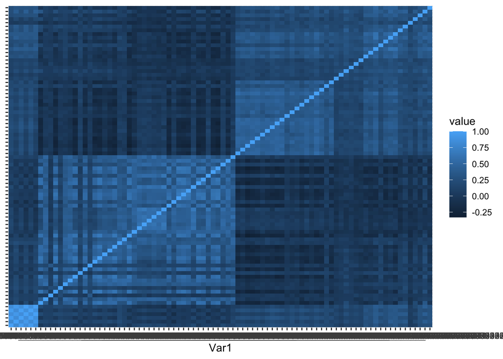

```r
cor_matrix <- round(cor(top_500), 2)
melted_cor_matrix <- melt(cor_matrix)
ggplot(data = melted_cor_matrix, aes(x=Var1, y=Var2, fill=value)) +
  geom_tile() + theme(axis.title.y=element_blank(),
        axis.text.y=element_blank())
```

## Clustering

Compute and visualize a hierarchical clustering of the samples, use package `hclust`

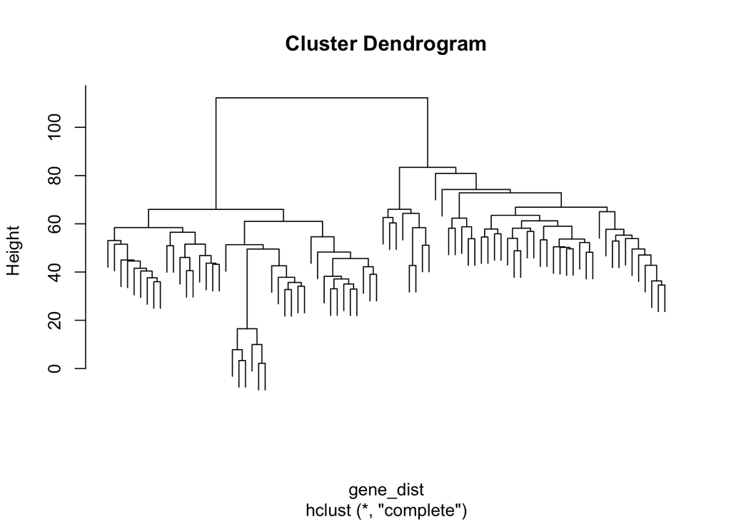

```r
gene_dist <- dist(t(top_500))
clustered <- hclust(gene_dist, method = "complete", members = NULL)
plot(clustered, labels = FALSE)
```

## Heatmap

Use the package `pheatmap` to generate a heatmap of the expression data.

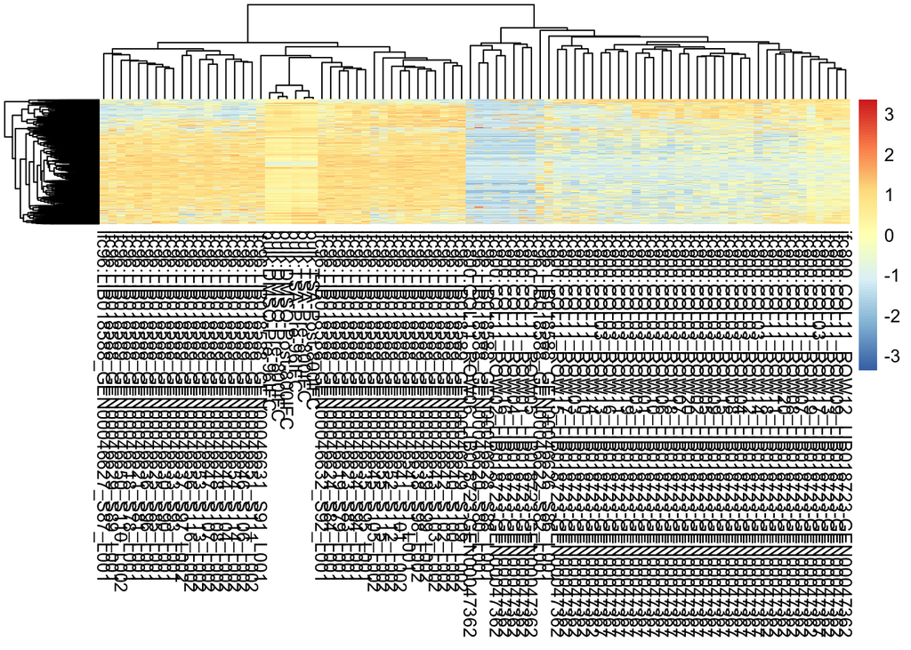

```r
pheatmap(top_500,
        colorRampPalette(rev(brewer.pal(n = 7, name ="RdYlBu")))(100),
        cluster_rows = T,
        show_rownames = F,
        scale = "row",
        )
```

## PCA

In the exercise session, we saw a potential case where the normal PCA can be misleading.

- Generate the data on the left, plot it as a scatter plot and color the points based on their class label.
- Do the PCA, plot the variance explained by the principal components. Select $k$ such that you explain $80\%$ of the variance in your data.
- Explain why this problem happens.
- Try to solve the problem with your desired method and do the PCA, and plot the variance explained by your PCs. Select $k$ in order to explain $80\%$ of the variance in your data. Is the $k$ different in comparison to the previous case?

I didn’t figure out the difference between computing a regular PCA and a non-regular PCA. Since I got more than 2 dimension, I guess that I computed a non-regular PCA.

```r
top_500.pca <- prcomp(top_500, center = TRUE,scale. = TRUE)
summary(top_500.pca) # cumulative proportion of variance > 80% for PC 35, i.e. k = 35
```

```
## Importance of components:
##                           PC1    PC2     PC3     PC4    PC5     PC6     PC7
## Standard deviation     4.1244 3.6606 2.49989 1.93008 1.5322 1.25572 1.22282
## Proportion of Variance 0.1978 0.1558 0.07267 0.04332 0.0273 0.01834 0.01739
## Cumulative Proportion  0.1978 0.3536 0.42629 0.46960 0.4969 0.51524 0.53262
##                            PC8     PC9    PC10    PC11    PC12    PC13    PC14
## Standard deviation     1.13111 1.11134 1.09825 1.05559 1.02694 1.00136 0.98345
## Proportion of Variance 0.01488 0.01436 0.01403 0.01296 0.01226 0.01166 0.01125
## Cumulative Proportion  0.54750 0.56186 0.57589 0.58884 0.60111 0.61277 0.62401
##                           PC15    PC16   PC17    PC18    PC19    PC20   PC21
## Standard deviation     0.97039 0.96058 0.9546 0.94255 0.92675 0.90289 0.8993
## Proportion of Variance 0.01095 0.01073 0.0106 0.01033 0.00999 0.00948 0.0094
## Cumulative Proportion  0.63496 0.64569 0.6563 0.66662 0.67661 0.68609 0.6955
##                           PC22    PC23    PC24    PC25    PC26    PC27    PC28
## Standard deviation     0.88976 0.87825 0.86045 0.85551 0.84244 0.83545 0.82652
## Proportion of Variance 0.00921 0.00897 0.00861 0.00851 0.00825 0.00812 0.00794
## Cumulative Proportion  0.70469 0.71366 0.72227 0.73078 0.73904 0.74715 0.75509
##                           PC29    PC30    PC31    PC32    PC33    PC34    PC35
## Standard deviation     0.82327 0.81669 0.80800 0.79879 0.78526 0.77893 0.76506
## Proportion of Variance 0.00788 0.00776 0.00759 0.00742 0.00717 0.00706 0.00681
## Cumulative Proportion  0.76298 0.77073 0.77832 0.78574 0.79291 0.79997 0.80677
##                           PC36    PC37    PC38    PC39    PC40    PC41    PC42
## Standard deviation     0.75961 0.75544 0.74558 0.73699 0.72634 0.71583 0.70879
## Proportion of Variance 0.00671 0.00664 0.00646 0.00632 0.00613 0.00596 0.00584
## Cumulative Proportion  0.81348 0.82012 0.82658 0.83290 0.83903 0.84499 0.85083
##                           PC43    PC44    PC45    PC46    PC47    PC48    PC49
## Standard deviation     0.70416 0.69362 0.68812 0.68181 0.67914 0.67065 0.65814
## Proportion of Variance 0.00577 0.00559 0.00551 0.00541 0.00536 0.00523 0.00504
## Cumulative Proportion  0.85660 0.86219 0.86770 0.87310 0.87847 0.88370 0.88873
##                          PC50    PC51   PC52   PC53    PC54   PC55    PC56
## Standard deviation     0.6490 0.64348 0.6356 0.6292 0.62416 0.6150 0.60771
## Proportion of Variance 0.0049 0.00481 0.0047 0.0046 0.00453 0.0044 0.00429
## Cumulative Proportion  0.8936 0.89845 0.9031 0.9077 0.91228 0.9167 0.92097
##                           PC57    PC58    PC59    PC60    PC61    PC62    PC63
## Standard deviation     0.60270 0.59635 0.58449 0.57972 0.57594 0.56653 0.55885
## Proportion of Variance 0.00422 0.00414 0.00397 0.00391 0.00386 0.00373 0.00363
## Cumulative Proportion  0.92519 0.92933 0.93330 0.93721 0.94107 0.94480 0.94843
##                           PC64    PC65    PC66    PC67    PC68    PC69    PC70
## Standard deviation     0.54946 0.54467 0.53351 0.52294 0.51995 0.51327 0.50695
## Proportion of Variance 0.00351 0.00345 0.00331 0.00318 0.00314 0.00306 0.00299
## Cumulative Proportion  0.95194 0.95539 0.95870 0.96188 0.96502 0.96809 0.97107
##                           PC71    PC72    PC73    PC74   PC75    PC76    PC77
## Standard deviation     0.50118 0.49365 0.48684 0.48122 0.4727 0.46416 0.45882
## Proportion of Variance 0.00292 0.00283 0.00276 0.00269 0.0026 0.00251 0.00245
## Cumulative Proportion  0.97399 0.97683 0.97958 0.98228 0.9849 0.98738 0.98983
##                           PC78    PC79    PC80    PC81    PC82    PC83    PC84
## Standard deviation     0.43970 0.42627 0.42398 0.40935 0.28550 0.19404 0.16563
## Proportion of Variance 0.00225 0.00211 0.00209 0.00195 0.00095 0.00044 0.00032
## Cumulative Proportion  0.99208 0.99419 0.99628 0.99823 0.99918 0.99961 0.99993
##                           PC85    PC86
## Standard deviation     0.06027 0.04677
## Proportion of Variance 0.00004 0.00003
## Cumulative Proportion  0.99997 1.00000
```

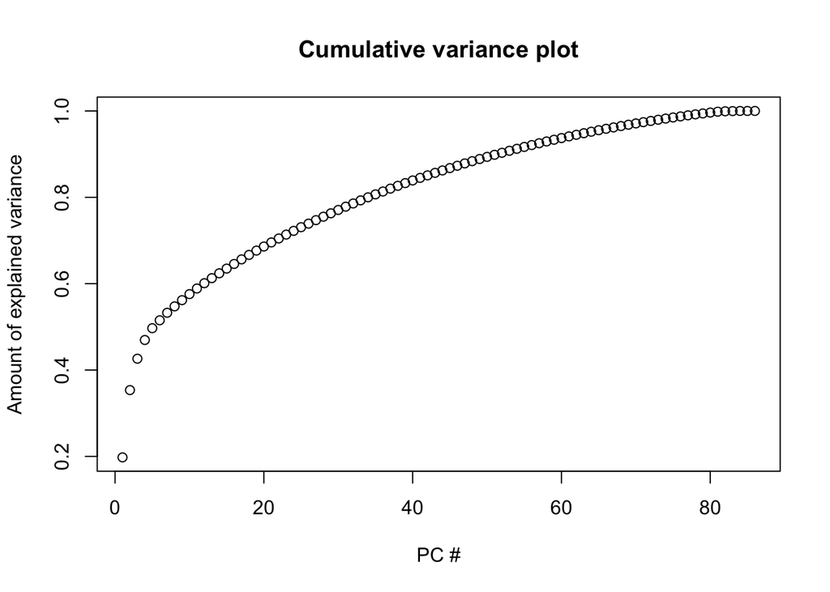

```r
cumpro <- cumsum(top_500.pca$sdev^2/sum(top_500.pca$sdev^2))
plot(cumpro, xlab = "PC #", ylab ="Amount of explained variance", main = "Cumulative variance plot")
```

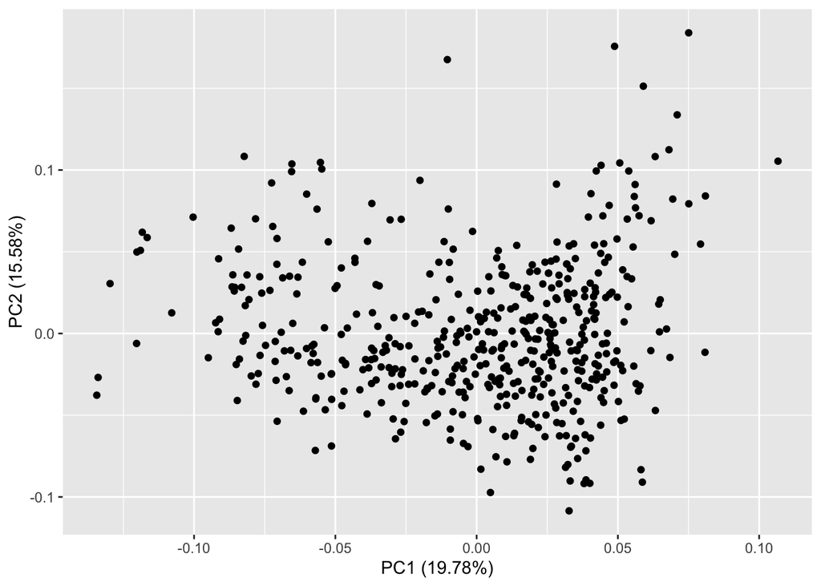

```r
autoplot(top_500.pca)
```